# A metadata convention for processed acoustic data from active acoustic systems

ICES WGFAST Topic Group, TG-AcMeta  
version 2.0, 15 March 2020

International Council for the Exploration of the Sea  
Conseil International pour l’Exploration de la Mer

H. C. Andersens Boulevard 44-46  
DK-1553 Copenhagen V  
Denmark  
Telephone (+45) 33 38 67 00  
Telefax (+45) 33 93 42 15  
www.ices.dk  
info@ices.dk

Recommended format for purposes of citation:

ICES. 2020. A metadata convention for processed acoustic data from active acoustic systems. Series of ICES Survey Protocols SISP 4-TG-AcMeta. 48 pp.

Series Editor: Emory D. Anderson

The material in this report may be reused for non-commercial purposes using the recommended citation. ICES may only grant usage rights of information, data, images, graphs, etc. of which it has ownership. For other third-party material cited in this report, you must contact the original copyright holder for permission. For citation of datasets or use of data to be included in other databases, please refer to the latest ICES data policy on ICES website. All extracts must be acknowledged. For other reproduction requests please contact the General Secretary.

This document is the product of an Expert Group under the auspices of the International Council for the Exploration of the Sea and does not necessarily represent the view of the Council. ISBN 978-87-7482-191-5  
ISSN 2304-6252

© 2020 International Council for the Exploration of the Sea

## Background and Terms of reference

The ICES Working Group on Fisheries Acoustics, Science and Technology (WGFAST) meeting in 2010, San Diego USA recommended the formation of a Topic Group that will bring together a group of expert acousticians to develop standardised metadata protocols for active acoustic systems. Through annual meetings in 2011-2013 and email correspondence the Topic Group on Acoustic Metadata (TG-AcMeta) developed a metadata convention for active acoustic data which is presented in this document.

The terms of reference for TG-AcMeta were “To develop standardised metadata protocols to suit requirements for data acquisition, processing, quality control and data dissemination of calibrated integrated active acoustic backscatter data. This includes data from a range of platforms such as Ships of Opportunity including research, merchant and commercial fishing vessels, moorings, AUV’s and acoustic instruments such as calibrated single- and multi-beam acoustic systems.”

## 1. Purpose of this document

Metadata is data describing data, and should allow potential users to determine the fitness for their purposes of that data from the metadata alone, without having to access the actual data. A metadata convention is a systematic set of metadata attributes that have been developed to describe a particular genre or type of data. This document describes a metadata convention that details the attribute fields necessary to describe water column backscatter data obtained from active acoustic systems.

This convention is not intended to conform to general metadata standards, such as FGDC, ISO:19115/19139, etc., nor to describe a metadata profile consistent with such standards. Essentially it describes a set of attributes to be included with the acoustic data itself to make a fully self-documenting data set. In addition to these, it also defines best practice for storing and managing fisheries acoustic data by providing a standard approach. That said, the metadata elements described here include all those necessary to populate any aggregated (or even global) metadata catalogue describing the available bioacoustic datasets managed in multiple institutional repositories.

It is recommended that processed acoustic data is stored in SI units of linear s<sub>v</sub> (m<sup>-1</sup>). Depending on the purpose, acoustic backscattering data is sometimes stored in a number of other forms including S<sub>v</sub>, volume backscatter in logarithmic form (dB re 1m<sup>-1</sup>), area backscattering coefficient s<sub>a</sub> (m<sup>2</sup> m<sup>-2</sup>), or scaled to nautical area scattering coefficient, s<sub>A</sub> (aka NASC, m<sup>2</sup> nmi<sup>-2</sup>) (MacLennan *et al.*, 2002). The actual form of the backscattering data needs to be specified as part of the data attributes and the dimensions of the echo integration cell also specified.

This convention was developed for processed acoustic data, but has relevance for archiving raw acoustic data. Processed acoustic backscatter data are generated by applying procedures to the instrument acquired acoustic data (i.e., raw data) that address data quality and calibration and, in many cases, resampling to a lower resolution than the acquired data. Unless stated otherwise in the metadata, appropriate calibration offsets and time varied gain (TVG) corrections will have been applied. Metadata attribute fields are provided that will allow description of processing procedures specific to the data set.

In many cases the cost of collecting acoustic data is significant and adhering to this metadata convention will facilitate the discovery, reuse, and exchange of processed acoustic data while ensuring its longevity.

## 2. Global attributes

The metadata attribute fields in this document build on existing conventions and are presented following the netCDF (network Common Data Format) (Rew and Davis, 1990; Unidata, 2017) format of global attributes. The global attributes describe the overall contents of the file and allow for data discovery. Global attributes can be thought of as conveying five kinds of information:

- What: What are the data in the dataset?
- Where: The spatial coverage of the data.
- When: The temporal coverage of the data.
- Who: Who produced the data?
- How: How were the data produced and how are they being made available?

All fields should be human-readable and can be of either ‘character’ or ‘numeric’ type. Where applicable, metadata attribute definitions will state that controlled vocabulary should be used. Use of controlled vocabulary aids consistency, accuracy, interoperability, and data discovery. Standard lists for controlled vocabulary developed specifically for this metadata convention are given in Appendix B. If the appropriate words are not present in the standard list users should provide their own terminology. The standard lists can be extended according to user feedback to accommodate new terminologies in future versions of this metadata convention.

Wherever possible, the global attributes are based on established authorities. In some instances the metadata attribute may cite other authorities, while other metadata attributes may be unique to this metadata convention. Where they exist, the relevant authority is cited for each of the attribute fields. A table of the various metadata authorities is given in Appendix A.

The metadata attributes are grouped according to logical categories. This is done to help both author and reader navigate the metadata record, but it is important to note that this does not describe a formal hierarchical structure. The metadata record of this convention is effectively a continuous list. Thus each global attribute must have a unique name for it to be unambiguously identified. Attribute names that are sourced from existing authorities are by necessity identical to that used by the authority in order to facilitate automatic harvesting of metadata. To ensure uniqueness, non-authoritative attributes are prefixed with the category name of this metadata convention. White spaces or blank characters are not allowed in attribute names as these are not supported by some of the established authorities (e.g. CF, the NetCDF Climate and Forecast Metadata Convention) and the underscore ‘_’ character is used instead. Specific categories of ship and mooring attributes have been developed for this current version of the metadata convention. Further development of metadata attribute fields for other acoustic systems (e.g. autonomous underwater vehicles, gliders, towed bodies, acoustic lenses, and parametric arrays) can be developed as required, following the form of existing conventions used in this document.

There is no constraint on the addition of extra metadata attributes to fully describe a dataset. Such extra attributes would be a super-set of the attributes of this convention and might be specific to a particular institution but their presence would not violate this convention.

## 3. Implementation of metadata convention

This document describes a metadata convention for processed acoustic data. It is assumed that appropriate data and metadata management of unprocessed acoustic data files will be in place, discussion of which is beyond the scope of this document.

Processed acoustic data and metadata may be held in a variety of formats including, but not limited to, relational databases, Extensible Markup Language (XML), JavaScript Object Notation (JSON), Network Common Data Form (netCDF) and Hierarchical Data Format (HDF). Storage of the data and associated metadata is a question of implementation and is not mandated or defined by this document. When choosing a data format some key considerations are ease of data exchange, visibility of data and metadata, and potential for automated harvesting of metadata. It is recommended that guidance and assistance from metadata experts is sought when realizing this metadata convention in a specific implementation format.

## 4. Summary of metadata categories

**Metadata Record**

Uniform resource identifier (URI) that uniquely identifies the metadata record.

**Mission metadata**

Metadata that gives a high level description of the overarching initiative (e.g. mission, project, ocean observing system) under which the acoustic data were collected.

**Cruise metadata**

Attributes that describe the cruise from which the acoustic data were acquired. Metadata should provide information that readily enables the cruise to be identified and be aware of cruise objectives, other instrumentation, and data acquired.

**Ship metadata**

Attributes that describe the ship from which acoustic data were collected. Metadata should provide information that uniquely identifies the ship and its basic specifications to enable an understanding of the type of ship and its purpose.

**Platform metadata**

Attributes that describe the platform from which acoustic data were collected.

**Transect metadata**

Attributes that describe transect data. Transect metadata would normally apply to acoustic data from a moving platform.

**Instrument metadata**

Attributes that describe the acoustic instrument that recorded the raw data from which the processed data were derived.

**Ancillary instruments**

Attributes that provide the opportunity to list ancillary instruments that may be of relevance to the acoustic data set.

**Calibration metadata**

Attributes that describe calibration procedures and calibration accuracy and precision.

**Data acquisition metadata**

Attributes that describe the data acquisition process.

**Data processing metadata**

Attributes that describe the data processing procedures. Data processing procedures may be complex and difficult to capture in a simple list of attributes. Therefore links to documents that give more comprehensive descriptions of processing procedures should be given if appropriate.

**Dataset metadata**

Attributes that describe the set of data. Some attributes will vary with each data file and may be automatically generated from the data file. When possible, automatic generation of dataset attribute metadata is preferred to reduce effort and the possibility of human error. Other attributes will need to be manually generated. In many cases attributes may be unchanged between datasets; hence the use of a metadata template which includes stable attributes may be beneficial.

**Data metadata**

Attributes that describe the data in a dataset, including the type of scattering quantity that is stored and the data horizontal and vertical dimensions.

## 5. Description of metadata category table headers

**Attribute name**

**Definition**

Description of attribute.

**Data type**

S for string, N for numeric

**Units**

If applicable, the units to be used for numeric attributes, using the SI standard.

**Authority**

Where they exist, the relevant authority is cited for each of the attribute fields. The field is left blank if no authority exists.

**Obligation**

Following Dublin Core documentation (Dublin Core, 2004), Obligation ‘indicates whether the element is required to always or sometimes be present. In this application profile, the obligation can be: mandatory (M), mandatory if applicable (MA), strongly recommended (R) or optional (O). Mandatory ensures that some of the elements are always supported and mandatory if applicable means that this element must be supported if the information is available. An element with a mandatory obligation must have a value. The strongly recommended and the optional elements should be filled with a value if the information is appropriate to the given resource but if not, they may be omitted.’ An example of an MA field would be attributes in the mooring table that are only populated if the data relates to the mooring in some way.

**Maximum occurrences**

## 6. Definition of attributes for active acoustic metadata

### 6.1. Category: Metadata record

| Attribute name | Definition | Data type | Units | Authority | Obligation | Maximum occurrences |
| --- | --- | --- | --- | --- | --- | --- |
| convention_name | Name of this convention. “A metadata convention for processed acoustic data from active acoustic systems” | S |  |  | M | 1 |
| convention_author | “ICES WGFAST Topic Group, TG-AcMeta” | S |  |  | M | 1 |
| convention_year | e.g. 2016 | N |  |  | M | 1 |
| convention_organisation | International Council for the Sea (ICES) | S |  |  | M | 1 |
| convention_publisher | The Series of ICES Survey Protocols (SISP) http://www.ices.dk/publications/our-publications/Pages/Survey-Protocols.aspx | S |  |  | M | 1 |
| convention_version | A label that states the convention version that the metadata conforms to. Must be of the form *major.minor* where *major* and *minor* are non-negative integers separated by a full stop, aka period (.)… | S |  |  | M | 1 |
| convention_reference | Record the reference for this convention. Note that while the convention version label is included in the convention reference as per the example full entry below, the authoritative version label is g… | S |  |  | M | 1 |
| Uniform_resource_identifier | Uniform resource identifier (URI) that uniquely identifies the name and location of the metadata record. | S |  |  | O | 1 |

### 6.2. Category: Mission attributes

| Attribute name | Definition | Data type | Units | Authority | Obligation | Maximum occurrences |
| --- | --- | --- | --- | --- | --- | --- |
| mission_name | Name of mission | S |  |  | M | 1 |
| mission_abstract | Free text description of the mission, its purpose, scientific objectives and area of operation. Other instruments and experiments within the mission which may or may not relate directly to the acousti… | S |  |  | M | 1 |
| mission_start_date | Start date of mission in ISO 8601 format including local time zone. For example, a local time of 18:00 on the 24th of October 2008 would be represented as 2008-10-24T08:00:00Z +10 (local) | S |  |  | M | 1 |
| mission_end_date | As per mission_start_date | S |  |  | MA | 1 |
| principal_investigator | Name of the principal investigator in charge of the mission | S |  | IMOS | M | 1 |
| principal_investigator_email | Principal investigator e-mail address | S |  | IMOS | M | N |
| institution | Name of the institute, facility, or company where the original data were produced | S |  | CF | M | N |
| data_centre | Data centre in charge of the data management or party who distributed the resource | S |  | IMOS | M | N |
| data_centre_email | Data centre contact e-mail address | S |  | IMOS | M | N |
| mission_id | ID code of mission | S |  |  | M | 1 |
| mission_platform | Platform type (see Section B.1, Standard lists) | S |  |  | M | N |
| creator | An entity primarily responsible for making the resource. | S |  | Dublin core | M | N |
| contributor | An entity responsible for making contributions to the resource | S |  | Dublin core | M | N |
| mission_comments | Free text field for relevant information that might not be captured by the defined attributes | S |  |  | O | 1 |

### 6.3. Category: Cruise attributes

| Attribute name | Definition | Data type | Units | Authority | Obligation | Maximum occurrences |
| --- | --- | --- | --- | --- | --- | --- |
| cruise_name | Formal name of cruise as recorded by cruise documentation or institutional data centre | S |  |  | MA | 1 |
| cruise_description | Free text field to describe the cruise. May include list of objectives of the cruise. For example scientific survey, commercial fishing, resupply, or combinations of these. | S |  |  | MA | 1 |
| cruise_summary_report | Published or web-based references that links to the cruise report. SeaDataNet - Pan European Infrastructure for Ocean and Marine Data Management have a well developed Cruise Summary Report (CSR) syste… | S |  | ICES/SeaDataNet | MA | 1 |
| cruise_area_description | List main areas of operation (e.g. Southern Pacific Ocean, Chatham Rise Region; Indian Ocean High Seas) | S |  |  | MA | N |
| cruise_start_date | Start date of cruise in ISO 8601 format. For example, a local time of 18:00 on the 24th of October 2008 would be represented as 2008-10-24T08:00:00Z +10 (local). | S |  |  | MA |  |
| cruise_end_date | see cruise_start_date | S |  | IMOS | MA | 1 |
| cruise_id | Cruise id where one exists. | S |  | IMOS | O | 1 |
| cruise_northlimit | The constant coordinate for the northernmost face or edge | N |  | Dublin core* | MA | 1 |
| cruise_eastlimit | The constant coordinate for the easternmost face or edge | N |  | Dublin core* | MA | 1 |
| cruise_southlimit | The constant coordinate for the southernmost face or edge | N |  | Dublin core* | MA | 1 |
| cruise_westlimit | The constant coordinate for the westernmost face or edge | N |  | Dublin core* | MA | 1 |
| cruise_uplimit | The constant coordinate for the uppermost face or edge in the vertical, z, dimension. | N |  | Dublin core* | MA | 1 |
| cruise_downlimit | The constant coordinate for the lowermost face or edge in the vertical, z, dimension. | N |  | Dublin core* | MA | 1 |
| cruise_units | The units of unlabelled numeric values of cruise_northlimit, cruise_eastlimit, cruise_southlimit, cruise_westlimit. Units specified as appropriate to the projection. E.g. geographic coordinates specif… | S |  | Dublin core* | MA | 1 |
| cruise_zunits | The units applying to unlabelled numeric values of cruise_uplimit, cruise_downlimit. SI units are 'm'. | S |  | Dublin core* | MA | 1 |
| cruise_projection | The name of the projection used with any parameters required, such as ellipsoid parameters, datum, standard parallels and meridians, zone, etc. | S |  | Dublin core* | MA | 1 |
| cruise_start_port | Commonly used name for the port where cruise started | S |  |  | O | 1 |
| cruise_end_port | Commonly used name for the port where cruise ended | S |  |  | O | 1 |
| cruise_start_BODC_code | Name of port from where cruise starts. Recommend use of British Oceanographic Data Centre (BODC) port gazetteer: + http://seadatanet.maris2.nl/v_bodc_vocab/search.asp?name=(C381)%20Ports+Gazetteer&l=C… | S |  | BODC ports gazetteer | O | 1 |
| cruise_end_BODC_code | see cruise_start_BODC_code | S |  | BODC ports gazetteer | O | 1 |
| cruise_comments | Free text field for relevant information that might not be captured by the defined attributes | S |  |  | O | 1 |

* Dublin core DCMI Bounding Box Encoding Scheme - see http://dublincore.org/documents/dcmi-box/index.shtml

### 6.4. Category: Ship attributes

| Attribute name | Definition | Data type | Units | Authority | Obligation | Occurrences |
| --- | --- | --- | --- | --- | --- | --- |
| ship_name | Name of the ship | S |  |  | MA | 1 |
| ship_type | Describe type of ship that is hosting the acoustic instrumentation. (See first three rows in Section B.1, Standard lists) | S |  |  | MA | 1 |
| ship_code | For example, in-house code associated with ship, e.g. SS = Southern Surveyor or ship national identifier | S |  |  | O | 1 |
| ship_platform_code | ICES database of known ships. See http://vocab.ices.dk/Request/Login.aspx?ReturnUrl=%2frequest. Requests can be made to add new vessels to the database by contacting accessions@ices.dk | S |  | ICES/SeaDataNet | MA | 1 |
| ship_platform_class | ICES controlled vocabulary for platform class. http://vocab.ices.dk/?ref=311 | S |  | ICES/SeaDataNet | MA | 1 |
| ship_callsign | Ship call sign | S |  |  | MA | 1 |
| ship_alt_callsign | Alternative call sign if the ship has more than one. | S |  |  | O | 1 |
| ship_IMO | Ship’s International Maritime Organisation ship identification number. | S |  |  | O | 1 |
| ship_operator | Name of organisation or company which operates the ship | S |  |  | MA | 1 |
| ship_length | Overall length of the ship | N | m |  | MA | 1 |
| ship_breadth | The width of the ship at its widest point | N | m |  | R | 1 |
| ship_tonnage | Gross tonnage of the ship | N | t |  | R | 1 |
| ship_engine_power | The total power available for ship propulsion | N | kW |  | R | 1 |
| ship_noise_design | For example, ICES 209 compliant (Mitson, 1995). Otherwise description of noise performance of the ship. | S |  |  | R | 1 |
| ship_acknowledgement | Any users (including re-packagers) of this data are required to clearly acknowledge the source of the material in this format. For example, ship of opportunity - acknowledge contribution by ship and c… | S |  |  | R | 1 |
| ship_comments | Free text field for relevant information that might not be captured by the defined attributes | S |  |  | O | 1 |

### 6.5. Category. Platform attributes

| Attribute name | Definition | Data type | Units | Authority | Obligation | Maximum occurrences |
| --- | --- | --- | --- | --- | --- | --- |
| platform_class | Controlled vocabularly for class of plaform. (see http://vocab.ices.dk/?ref=311) | S |  |  | MA | 1 |
| platform_description | Free text field to describe the platform. This may include a description of the platform, its objectives, details about the cruise (if applicable) and other information relevant to the data being coll… | S |  |  | MA | 1 |
| platform_depth | Seafloor depth at platform site | N | m |  | MA | 1 |
| platform_northlimit | The constant coordinate for the northernmost face or edge | N |  | Dublin core* | MA | 1 |
| platform_eastlimit | The constant coordinate for the easternmost face or edge | N |  | Dublin core* | MA | 1 |
| platform_southlimit | The constant coordinate for the southernmost face or edge | N |  | Dublin core* | MA | 1 |
| platform_westlimit | The constant coordinate for the westernmost face or edge | N |  | Dublin core* | MA | 1 |
| platform_uplimit | The constant coordinate for the uppermost face or edge in the vertical, z, dimension. | N |  | Dublin core* | MA | 1 |
| platform_downlimit | The constant coordinate for the lowermost face or edge in the vertical, z, dimension. | N |  | Dublin core* | MA | 1 |
| platform_units | The units unlabelled numeric values of platform_northlimit, platform_eastlimit, platform_southlimit, platform_westlimit. Units specified as appropriate to the projection. E.g. geographic coordinates s… | S |  | Dublin core* | MA | 1 |
| platform_zunits | The units of unlabelled numeric values of platform_uplimit, platform_downlimit. SI units are 'm'. | S |  | Dublin core* | MA | 1 |
| platform_projection | The name of the projection used with any parameters required, such as ellipsoid parameters, datum, standard parallels and meridians, zone, etc | S |  | Dublin core* | MA | 1 |
| platform_deployment_date | Start time of platform deployment in ISO 8601 format. For example, a local time of 18:00 on the 24<sup>th</sup> of October 2008 would be represented as 2008-10-24T08:00:00Z +10 (local). | S |  |  | MA | 1 |
| platform_retrieval_date | see platform_deployment_date | S |  |  | MA | 1 |
| platform_code | e.g. platform ID | S |  |  | O | 1 |
| platform_site_name | e.g. name of location where platform is deployed | S |  |  | O | 1 |
| platform_operator | Name of organisation which operates the platform | S |  |  | MA | N |
| platform_comments | Free text field for relevant information that might not be captured by the defined attributes | S |  |  | O | 1 |

* Dublin core DCMI Bounding Box Encoding Scheme - see http://dublincore.org/documents/dcmi-box/index.shtml

### 6.6. Category: Transect attributes

| Attribute name | Definition | Data type | Units | Authority | Obligation | Maximum occurrences |
| --- | --- | --- | --- | --- | --- | --- |
| transect_name | Name of the transect | S |  |  | O | 1 |
| transect_id | Identifier for the transect | S |  |  | O | 1 |
| transect_description | Description of the transect, its purpose, and main activity | S |  |  | MA | 1 |
| transect_related_activity | Describe related activities that may occur on the transit | S |  |  | O | 1 |
| transect_start_time | Start time of the transect in ISO 8601 format. For example, a local time of 18:00 on the 24th of October 2008 would be represented as 2008-10-24T08:00:00Z +10 (local). | S |  |  | MA | 1 |
| transect_end_time | see transect_start_time | S |  |  | MA | 1 |
| transect_northlimit | The constant coordinate for the northernmost face or edge | N |  | Dublin core* | MA | 1 |
| transect_eastlimit | The constant coordinate for the easternmost face or edge | N |  | Dublin core* | MA | 1 |
| transect_southlimit | The constant coordinate for the southernmost face or edge | N |  | Dublin core* | MA | 1 |
| transect_westlimit | The constant coordinate for the westernmost face or edge | N |  | Dublin core* | MA | 1 |
| transect_uplimit | The constant coordinate for the uppermost face or edge in the vertical, z, dimension. | N |  | Dublin core* | MA | 1 |
| transect_downlimit | The constant coordinate for the lowermost face or edge in the vertical, z, dimension. | N |  | Dublin core* | MA | 1 |
| transect_units | The units of unlabelled numeric values of transect_northlimit, transect_eastlimit, transect_southlimit, transect_westlimit. Units specified as appropriate to the projection. E.g. geographic coordinate… | S |  | Dublin core* | MA | 1 |
| transect_zunits | The units of unlabelled numeric values of transect_uplimit, transect_downlimit. SI units are 'm'. | S |  | Dublin core* | MA | 1 |
| transect_projection | The name of the projection used with any parameters required, such as ellipsoid parameters, datum, standard parallels and meridians, zone, etc | S |  | Dublin core* | MA | 1 |
| transect_comments | Free text field for relevant information that might not be captured by the defined attributes | S |  |  | O | 1 |

* Dublin core DCMI Bounding Box Encoding Scheme - see http://dublincore.org/documents/dcmi-box/index.shtml

### 6.7. Category: Instrument attributes

| Attribute name | Definition | Data type | Units | Authority | Obligation | Maximum occurrences |
| --- | --- | --- | --- | --- | --- | --- |
| instrument_frequency | Frequency of the transceiver/transducer combination in kHz. Some systems such as broadband and multi-beam will have a range of frequencies. If so, specify the minimum, maximum and centre frequency | S | kHz |  | M | 1 |
| instrument_transducer_location | Location of installed transducer. Refer to Section B.2 for a list of standard transducer locations. | S |  |  | M | 1 |
| instrument_transducer_manufacturer | Transducer manufacturer | S |  |  | M | 1 |
| instrument_transducer_model | Transducer model | S |  |  | M | 1 |
| instrument_transducer_beam_type | For example 'single-beam, split-aperture'. See controlled vocabulary table for transducer types in Section B.3. | S |  |  | M | 1 |
| instrument_transducer_serial | Transducer serial number | S |  |  | R | N |
| instrument_transducer_depth | Mean depth of transducer face beneath the water surface. | N | m |  | O | 1 |
| instrument_transducer_orientation | Direction perpendicular to the face of the transducer. A simple description for a ship mounted sounder would be 'downward looking', a mooring could be 'upward looking'. If required Appendix C provides… | S |  |  | M | 1 |
| instrument_transducer_psi | Manufacturer specified transducer equivalent beam angle, expressed as \(10 \log_{10}(\psi)\), where \(\psi\) has units of steradians. Note this value is not necessarily used for processing. Check data… | N | dB |  | R | 1 |
| instrument_transducer_beam_angle_major | Major beam opening, also referred to athwartship angle. See Appendix D for description of beam geometry conventions | N | degrees |  | R | 1 |
| instrument_transducer_beam_angle_minor | Minor beam opening, also referred to alongship angle. See Appendix D for description of beam geometry conventions | N | degrees |  | R | 1 |
| instrument_transceiver_manufacturer | Transceiver manufacturer | S |  |  | M | 1 |
| instrument_transceiver_model | Transceiver model | S |  |  | M | 1 |
| instrument_transceiver_serial | Transceiver serial number | S |  |  | R | 1 |
| instrument_transceiver_firmware | Transceiver firmware version | S |  |  | R | 1 |
| instrument_comments | Free text field for relevant information that might not be captured by the defined attributes | S |  |  | O | 1 |

### 6.8. Category: Ancillary instrumentation

| Attribute name | Definition | Data type | Units | Authority | Obligation | Maximum occurrences |
| --- | --- | --- | --- | --- | --- | --- |
| ancillary_instrumentation | List suite of instruments and other equipment (e.g. net systems, CTD, ADCP) potentially relevant to the acoustic data set. | S |  |  | O | N |

### 6.9. Category: Calibration attributes

| Attribute name | Definition | Data type | Units | Authority | Obligation | Maximum occurrences |
| --- | --- | --- | --- | --- | --- | --- |
| calibration_date | Date of calibration in ISO 8601 format including local time zone. For example, a local time of 18:00 on the 24<sup>th</sup> of October 2008 would be represented as 2008-10-24T08:00:00Z +10 (local). | S |  |  | M | 1 |
| calibration_aquisition_method | Describe the method used to acquire calibration data. (see Section B.4, Standard lists) | S |  |  | M | 1 |
| calibration_processing_method | Describe method of processing that was used to generate calibration offsets. | S |  |  | M | 1 |
| calibration_accuracy_estimate | Estimate of calibration accuracy. Include a description and units so that it is clear what this estimate means (e.g. estimate might be expressed in dB or as a percentage). | S |  |  | M | 1 |
| calibration_report | URL or references to external documents which give a full account of calibration processing and results may be appropriate | S |  |  | M | 1 |
| calibration_comments | Free text field to for relevant information that might not be captured by the defined attributes | S |  |  | O | 1 |

### 6.10. Category: Data acquisition attributes

| Attribute name | Definition | Data type | Units | Authority | Obligation | Maximum occurrences |
| --- | --- | --- | --- | --- | --- | --- |
| data_aquisition_software_name | Name of software that controls echosounder and its data logging | S |  |  | R | 1 |
| data_acquisition_software_version | Version of software that controls echosounder and its data logging | S |  |  | R | 1 |
| data_acquisition_stored_data_format | Name of the format in which data is stored. For example Simrad raw format, HAC. | S |  |  | M | 1 |
| data_acquisition_ping_duty_cycle | Free text field to describe ping duty cycle. For a ship system this may be continuous pinging at a certain rate. For a mooring this may describe the duty cycle. For example 10 minutes pinging at 1 pin… | S |  |  | M | 1 |
| data_acquisition_comments | Free text field for relevant information that might not be captured by the defined attributes | S |  |  | O | 1 |

### 6.11. Category: Data processing attributes

| Attribute name | Definition | Data type | Units | Authority | Obligation | Maximum occurrences |
| --- | --- | --- | --- | --- | --- | --- |
| data_processing_software_name | Name of software that was used to process raw acoustic data | S |  |  | M | N |
| data_processing_software_version | Version of software that was used to process raw acoustic data | S |  |  | M | N |
| data_processing_triwave_correction | Applies to Simrad ES60 and ES70 echosounders only. Simrad ES60/70 echosounders have an error function embedded in the raw data that overlays addition of to the data of a triangle wave of +/- 0.5dB pea… | S |  |  | MA | 1 |
| data_processing_channel_id | Unique identifier for each data channel. | S |  |  | R | 1 |
| data_processing_bandwidth | Bandwidth associated with processed data | N | kHz |  | R | 1 |
| data_processing_frequency | Transmit frequency associated with processed data | N | kHz |  | M | 1 |
| data_processing_transceiver_power | Nominal transceiver power | N | W |  | M | N |
| data_processing_transmit_pulse_length | Transmit pulse length | N | ms |  | M | N |
| data_processing_on_axis_gain | Total system gain value when calibration sphere is on-axis. This term accounts for whole of system calibration including the power source, the transducer directivity multiplied by its efficiency, and … | N |  |  | M | N |
| data_processing_on_axis_gain_units | Units for the data_processing_on_axis_gain attribute. Units may be in dB for some systems (e.g. Simrad) but on other instruments may be dimensionless numeric values | S |  |  | M | 1 |
| data_processing_Sacorrection | S<sub>A</sub> correction value (Simrad transceivers) | N | dB |  | O | 1 |
| data_processing_absorption | Absorption of sound by seawater value. Leave blank if absorption profile was used and give appropriate description in the data_processing_absorption_description field | N | dBm<sup>-1</sup> |  | R | 1 |
| data_processing_absorption_description | Describe (i) equation used to calculate absorption, (ii) source of input data into absorption calculation (e.g. model, XBT, CTD), (iii) arithmetic or geometric mean of depth-absorption profile or nomi… | S |  |  | R | 1 |
| data_processing_soundspeed | Sound speed used by transceiver. Leave blank if sound speed profile was used and give appropriate description in the data_process_soundspeed_description field | N | ms<sup>-1</sup> |  | R | 1 |
| data_processing_soundspeed_description | Describe (i) equation used to calculate sound speed, (ii) source of input data into sound speed calculation (e.g. model, XBT, CTD), (iii) arithmetic or geometric mean of depth-absorption profile or no… | S |  |  | R | 1 |
| data_processing_transducer_psi | Transducer equivalent beam angle, expressed as \(10 \log_{10}(\psi)\), where \(\psi\) has units of steradians. | N | dB |  | M | 1 |
| data_processing_comments | Free text field for relevant information that might not be captured by the defined attributes | S |  |  | O | 1 |

### 6.12. Category: Dataset attributes

| Attribute name | Definition | Data type | Units | Authority | Obligation | Maximum occurrences |
| --- | --- | --- | --- | --- | --- | --- |
| project | The scientific project that produced the data | S |  | NACDD | M | 1 |
| title | Short description of the dataset | S |  | NUG | M | 1 |
| abstract | A paragraph describing the dataset: type of data contained in the dataset, how the data was created, the creator of the dataset, the mission for which the data was created, the geospatial coverage of … | S |  | IMOS | M | 1 |
| history | Provides an audit trail for modifications to the original data. It should contain a separate line for each modification, with each line beginning with a timestamp and including user name, modification… | S |  | NUG | R | N |
| comment | Miscellaneous information about the data or methods used to produce it. Any free-format text is appropriate. Manually generated attribute. | S |  | CF | O | N |
| keywords | A comma separated list of key words and phrases. Keywords are an important tool in data discovery and the use of words or phrases from 'standard' vocabularies is encouraged to maximise the discoverabi… | S |  | NACDD | M | N |
| references | Published or web-based references that describe the data or the methods used to produce the data. If available, DOI’s (Digital Object Identifiers) should be given. | S |  | CF | M | N |
| doi | Digital Object Identifier (DOI) for project documentation | S |  | IDF | O | N |
| citation | The citation to be used in publications using the dataset should follow the format:"ProjectName. [year-of-data-download], [Title], [Data access URL], accessed [date-of-access]". Manually generated att… | S |  | IMOS | M | N |
| license | Describe the restrictions to data access and distribution. For example visit Australian National Data Service website AusGoal licensing framework (http://www.ands.org.au/publishing/licensing.html) whi… | S |  | NACDD | M | 1 |
| author_email | Email address of the person responsible for the creation of the dataset | S |  | IMOS | M | N |
| author | Name of the person responsible for the creation of the dataset | S |  | IMOS | M | N |
| distribution_statement | Statement describing data distribution policy, e.g., re-packagers of this data should include a statement that information about data quality and lineage is available from the metadata record and a st… | S |  | IMOS | M | 1 |
| date_created | The date on which the data was created in ISO 8601 format. Will vary with each data file, possibly automatically generated. For example, a local time of 18:00 on the 24<sup>th</sup> of October 2008 wo… | S |  | NACDD | M | N |
| northlimit | The constant coordinate for the northernmost face or edge | N |  | Dublin core* | MA | 1 |
| eastlimit | The constant coordinate for the easternmost face or edge | N |  | Dublin core* | MA | 1 |
| southlimit | The constant coordinate for the southernmost face or edge | N |  | Dublin core* | MA | 1 |
| westlimit | The constant coordinate for the westernmost face or edge | N |  | Dublin core* | MA | 1 |
| uplimit | The constant coordinate for the uppermost face or edge in the vertical, z, dimension. Reference edge for this attribute is the water surface. | N |  | Dublin core* | MA | 1 |
| downlimit | The constant coordinate for the lowermost face or edge in the vertical, z, dimension. Reference edge for this attribute is the water surface. | N |  | Dublin core* | MA | 1 |
| units | The units of unlabelled numeric values of northlimit, eastlimit, southlimit, westlimit. Units specified as appropriate to the projection. E.g. geographic coordinates specify 'signed decimal degrees', … | N |  | Dublin core* | MA | 1 |
| zunits | The units of unlabelled numeric values of uplimit, downlimit. **SI units are** 'm'. | N |  | Dublin core* | MA | 1 |
| projection | The name of the projection used with any parameters required, such as ellipsoid parameters, datum, standard parallels and meridians, zone, etc | S |  | Dublin core* | MA | 1 |
| dataset_linestring | OGC:SFS/WKT compliant LINESTRING geometry representing each transect. A LineString consists of a sequence of two or more vertices, along with all points along the linearly-interpolated curves (line se… | S |  |  | O | N |
| time_coverage_start | Start date of the data in UTC Date format is ISO 8601. For example, a local time of 18:00 on the 24<sup>th</sup> of October 2008 would be represented as 2008-10-24T08:00:00Z +10 (local). Will vary wit… | S |  | NACDD | M | 1 |
| time_coverage_end | see time_coverage_start | S |  | NACDD | M | 1 |
| dataset_comments | Free text field for relevant information that might not be captured by the defined attributes | S |  |  | O | 1 |

### 6.13. Category: Data attributes

It is usual and recommended for the cell dimensions (ping-axis interval and range-axis interval) to be stored for each data value to be stored with the data. These cell dimensions should also be defined in the metadata if possible. If cell dimensions do vary within the dataset then they cannot be specified in the metadata record and it will be essential that they are stored with the data. Similarly it is expected that time and position (if appropriate) of each data value will be stored with the data.

Attribute name

Definition

Data type

Units

Authority

Obligation

Maximum occurrences

data_acoustic_datatype

In what form is the acoustic data stored? Controlled vocabulary options include :

- Sv, Volume backscattering strength (dB re 1 m<sup>-1</sup>)
- s<sub>v</sub>, Volume backscattering coefficient (m<sup>-1</sup>)
- sA, Nautical area scattering coefficient (m2 nmi <sup>-2</sup>)
- s<sub>a</sub>, Area backscattering coefficient (m2 m<sup>-2</sup>)

S

M

data_ping_axis_interval_type

Ping-axis interval by which data have been binned.

Controlled vocabulary include:

- Time based intervals

  Time (minutes); Time (seconds); Time (hours); Time (day)
- Distance based intervals

  Distance (nautical miles); Distance (metres);Distance (kilometres)
- Ping based intervals

  Number of pings

User-defined interval types can be used if not on controlled vocabulary list.

S

M

1

data_ping_axis_interval_origin

Location of ping axis interval value in the ping axis interval.

Controlled vocabulary include:

Start

Middle

End

S

M

1

data_ping_axis_interval_value

Numeric value for data ping axis interval according to its specified type

Examples:

(1)

data_ping_axis_interval_type: Time (seconds)

data_ping_axis_interval_value: 600

(2)

data_ping_axis_interval_type: Distance (metres)

data_ping_axis_interval_value: 1000

(3)

data_ping_axis_interval_type: Number of pings

data_ping_axis_interval_value: 300

Notes:

If ping axis interval values vary within each dataset they cannot be specified as a single number in this metadata record. Leave this record blank if this is the case. Note that it would be usual for the ping axis interval information to be stored at the same level as the data itself.

N

MA

1

data_range_axis_interval_type

Range-axis interval by which data has been binned.

Controlled vocabulary include:

Range (metres)

Time (seconds)

User-defined interval type can be used if not on controlled vocabulary list.

S

M

1

data_range_axis_interval_origin

Location of ping axis range value in the range axis interval.

Controlled vocabulary include:

Start

Middle

End

S

m

M

1

data_range_axis_interval_value

Numeric value for data range axis interval according to its specified type, e.g.

data_range_axis_interval_value: 1000

SI units are 'm'

Notes:

If range axis interval values vary within each dataset they cannot be specified as a single number in this metadata record. Leave this record blank if this is the case. Note that it would be usual for the range axis interval information to be stored at the same level as the data itself.

N

MA

1

## Appendix A: Metadata authorities

Table 1. Authorities for various metadata attribute fields used in this convention or used for general reference:

| NetCDF | Network Common Data Form | http://www.unidata.ucar.edu/software/netcdf/docs/BestPractices.html http://en.wikipedia.org/wiki/Netcdf |
| --- | --- | --- |
| NUG | NetCDF User’s Guide | http://www.unidata.ucar.edu/software/netcdf/guide_toc.html |
| COARDS | Cooperative Ocean/Atmosphere Research Data Service | http://ferret.wrc.noaa.gov/noaa_coop/coop_cdf_profile.html |
| CF | NetCDF Climate and Forecast (CF) Metadata Convention | http://www.cfconventions.org/ http://cf-pcmdi.llnl.gov/ http://en.wikipedia.org/wiki/Climate_and_Forecast_Metadata_Conventions |
| NACDD | NetCDF Attribute Convention for Dataset Discovery | http://www.unidata.ucar.edu/software/netcdf-java/formats/DataDiscoveryAttConvention.html |
| Dublin Core | The Dublin Core Metadata Initiative (DCMI) | http://dublincore.org/ |
| IMOS | Integrated Marine Observing System | http://imos.org.au/fileadmin/user_upload/shared/emii/IMOS_netCDF_usermanual_v1.2.pdf |
| BASOOP | IMOS Bio-acoustic Ships of opportunity | http://imos.org.au/fileadmin/user_upload/shared/SOOP/plugin-SOOP-BA_NetCDF_manual_v1.1.pdf |
| Udunits | UniData units software | http://www.unidata.ucar.edu/software/udunits |
| ISO8601 | ISO standard for dates | http://www.iso.org/iso/home/standards/iso8601.htm |
| MMI | MMI Platform Ontology | http://mmi.svn.sourceforge.net/svnroot/mmi/mmisw/platform.owl |
| IDF | International DOI Foundation | http://www.doi.org/ |
| SeaDataNet | Pan-European infrastructure for ocean and marine data management | http://www.seadatanet.org/ |

## Appendix B: Standard lists for controlled vocabulary

### B.1. Category: Mission attributes: mission_platform; Ship attributes: ship_type

| Ship, research |
| --- |
| Ship, fishing |
| Ship, other |
| Buoy, moored |
| Buoy, drifting |
| Glider |
| Underwater vehicle, autonomous, motorised |
| Underwater vehicle, towed |
| Underwater vehicle, autonomous, glider |

- Controlled vocabulary sources from Marine Metadata Interoperability project (MMI, https://marinemetadata.org/), MMI Platform Ontology, http://mmi.svn.sourceforge.net/svnroot/mmi/mmisw/platform.owl

### B.2. Category: Instrument attributes: instrument_transducer_location

| Hull, keel |
| --- |
| Hull, lowered keel |
| Hull, blister |
| Hull, gondola |
| Towed, shallow |
| Towed, deep |
| Towed, deep, trawl net attached |
| Ship, pole |

### B.3. Category: Instrument attributes: instrument_transducer_beam_type

| Type | Comments |
| --- | --- |
| Single-beam | Single beam |
| Single-beam, split-aperture | Single beam transducer with elements divided into groups to provide information on the direction of arrival of echoes. Typically four equal quadrants but other groupings are possible. |
| Multi-beam | Multiple single beams. |
| Multi-beam, split-aperture | Multiple single beams with elements divided into groups to provide information on the direction of arrival of echoes. Typically four equal quadrants per beam but other groupings are possible. |

### B.4. Category: Calibration attributes: calibration_aquisition_method

[output not shown]

## Appendix C: Transducer orientation conventions

This Appendix was reproduced with permission from the Echoview 5.1 help file (see also www.echoview.com).

**About transducer geometry**

Transducer geometry in Echoview refers to the configurable location and orientation of [transducers](http://support.echoview.com/WebHelp/Reference/Glossary.htm#Transducer). This page covers:

- Overview of transducer geometry
- About transducer location
- About transducer orientation

For information about how transducer geometry affects displayed data and exports, see [What is affected by transducer geometry](http://support.echoview.com/WebHelp/Using_Echoview/What_is_effected_by_transducer_geometry.htm).

**Overview of transducer geometry**

Each transducer may be located in space and oriented as desired. Illustrated below is a schematic displaying the relative positions in space of a reference point, a GPS antenna and a transducer with non-vertical orientation. How to define location and orientation for each transducer is described below.

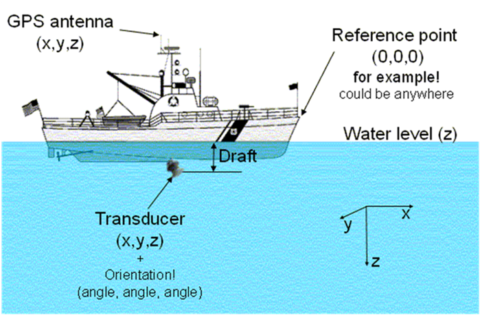

Transducers are always associated with a [platform](http://support.echoview.com/WebHelp/Reference/Glossary.htm#Platform). The reference point of the platform is at (0,0,0) by definition and defines the position of the platform in the real world (that is, the platform is considered to be, in the real world, wherever it’s reference point is).

The position of the reference point is not explicitly entered in Echoview, but all other positions are entered relative to it, wherever it may be.

Please note that the positive Z direction is downwards when the X-Y plane is horizontal (considered to be on a rigid platform that does not pitch and roll).

For many applications, such as a typical ship based echo integration survey with multiple downward looking transducers, the only aspect of transducer geometry required is the definition of transducer depth ([draft](http://support.echoview.com/WebHelp/Using_Echoview/About_transducer_draft.htm)), if desired. Other applications, such as multiple frequency TS techniques, surveys with non-vertical transducers, and applications that require the position of samples to be precisely located in the world, Echoview’s transducer geometry settings allow full specification of the transducer set up.

Echoview transducer geometry settings allow enough information to be stored about the location and orientation of transducers and GPS antennas to determine the geographic coordinates of any sample or single target in the acoustic beam - given the assumption of a stable platform with no pitch and no roll. In Echoview, some data formats may support roll data or roll and pitch data. For further information regarding relevant data formats and the effects of using roll and pitch data see [About roll data](http://support.echoview.com/WebHelp/Files,_filesets_and_variables/Variables/About_roll_data.htm) and [About pitch data](http://support.echoview.com/WebHelp/Files,_filesets_and_variables/Variables/About_pitch_data.htm).

Note: Transducer geometry calculations are not used in Echoview for calculating the geographic position of lines (and hence bathymetric data). Bottom picks are assumed to be at the position of the GPS antenna even if the beam is pointing at some angle to the vertical and the transducer is offset from the Reference point.

**About transducer location**

The relative location of the water level and GPS antenna and the location of each transducer are defined on the [Location page](http://support.echoview.com/WebHelp/Windows_and_Dialog_Boxes/Dialog_Boxes/Transducer_Properties_dialog_box.htm#Location_page) of the [Transducer Properties dialog box](http://support.echoview.com/WebHelp/Windows_and_Dialog_Boxes/Dialog_Boxes/Transducer_Properties_dialog_box.htm).

Locations are all defined relative to a system reference point. The system reference point may be any point defined relative to the transducer platform (it is not defined explicitly in Echoview, the locations of transducers, GPS antenna and water level are defined relative to it).

The coordinate system utilises three axes (X, Y and Z) and their orientation depends upon whether the platform is fixed or mobile.

**Fixed Platform**

The location of the system reference point is specified in geographic coordinates (latitude, longitude and altitude).

- The X axis is defined to run south-north (positive northwards, negative southwards)
- The Y axis is defined to run west-east (positive eastwards, negative westwards)
- The Z axis is defined to run vertically (positive downwards, negative upward)

**Mobile Platform**

The geographic location (latitude, longitude and altitude) of the GPS antenna is measured by a Global Positioning System (GPS) device. The location of the GPS antenna relative to the system reference point is specified in X, Y, Z coordinates (m). Hence the geographic location of the system reference point and the location of the face of each transducer can be determined in geographic coordinates (latitude, longitude and altitude) from the known position of the GPS antenna.

- The X axis is defined to run alongship (positive towards the bow, negative towards the stern)
- The Y axis is defined to run athwartship (positive towards starboard, negative towards port)
- The Z axis is considered to run vertically (positive downwards, negative upwards)

To determine the geographic location of a sample point or a single target in geographic coordinates it is also necessary to define the orientation of the transducer.

**About transducer orientation**

Transducers are not only located, but also oriented - that is, they point somewhere. Like location, orientation requires three parameters to be specified, in this case angles rather than coordinates. The orientation for each transducer is defined on the [Orientation page](http://support.echoview.com/WebHelp/Windows_and_Dialog_Boxes/Dialog_Boxes/Transducer_Properties_dialog_box.htm#Orientation_page) of the [TransducerProperties dialog box](http://support.echoview.com/WebHelp/Windows_and_Dialog_Boxes/Dialog_Boxes/Transducer_Properties_dialog_box.htm).

The X-Y-Z axes as defined above are taken as a reference for orientation. In summary:

**For fixed platforms:**

- The X axis runs south-north
- The Y axis runs west-east
- The Z axis runs up-down

**For mobile platforms:**

- The X axis runs stern-bow
- The Y axis runs port-starboard
- The Z axis runs up-down

Two angles are used to define the direction in which the acoustic axis is pointing (either elevation and azimuth angles or alongship and athwartship angles). A third angle called the rotation defines the direction of the [minor axis](http://support.echoview.com/WebHelp/Reference/Glossary.htm#Minor-axis) of the transducer relative to a vertical plane passing through the [beam axis](http://support.echoview.com/WebHelp/Reference/Glossary.htm#beam_axis). The rotation of the transducer can only be determined after the definition of the beam direction.

**Elevation and Azimuth**

The angles are defined as follows:

- **Elevation** is the angle between the beam axis and the positive Z axis.  
  Valid range is 0° to 180°.

| 0° | defines a vertically downward pointing beam |
| --- | --- |
| 90° | a horizontal beam |
| 180° | a vertically upward pointing beam |

- **Azimuth** is the angle between the beam axis and the positive X axis (measured clockwise when viewed in the positive Z direction).  
  Valid range is 0° to 360° .

| 0° | defines a northward (or forward) pointing beam |
| --- | --- |
| 90° | eastward (or starboard) pointing |
| 180° | southward (or aft) pointing |
| 270° | westward (or port) pointing |

If the elevation is 0° or 180° then Azimuth is equivalent to a rotation.

**Along and Athwartship (Mobile Platform only)**

The angles are defined as follows:

- **Alongship** is the angle between the beam axis and the Y-Z plane.  
  Valid range is -180° to 180° .

| 0° | defines a downward pointing beam in the Y-Z plane |
| --- | --- |
| -90° | a horizontal aft pointing beam |
| 90° | a horizontal forward pointing beam |
| -180° | an upward pointing beam in the Y-Z plane |
| 180° | an upward pointing beam in the Y-Z plane |

- **Athwartship** is the angle between the beam axis and the X-Z plane.  
  Valid range is -180° to 180° .

| 0° | defines a downward pointing beam in the X-Z plane |
| --- | --- |
| -90° | a horizontal port pointing beam |
| 90° | degrees a horizontal starboard pointing beam |
| -180° | an upward pointing beam in the X-Z plane |
| 180° | an upward pointing beam in the X-Z plane |

**Note:** Not all combinations of Alongship and Athwartship angle are valid. If one angle defines a downward pointing beam (-90° to 90°) and the other an upward pointing beam (-180° to -90° or 90° to 180°) they cannot be describing the same direction!

**Rotation**

- **Rotation** is the angle between the positive [minor-axis](http://support.echoview.com/WebHelp/Reference/Glossary.htm#Minor-axis) of the transducer and the vertical plane running through the beam axis (measured in the clockwise direction as seen from the transducer).

Valid range is 0° to 360°.

| 0° | an upward pointing positive minor-axis |
| --- | --- |
| 180° | a downward pointing positive minor-axis |

**In Summary**

To determine the three coordinates defining the beam orientation do the following:

1. Determine the pointing direction of the beam axis

   Use your choice of either elevation-azimuth angles or alongship-athwartship angles.
2. Determine the rotation angle of the transducer

   Remember that the zero reference for the rotation angle is the vertical plane running through the beam axis and therefore that the rotation coordinate can only be meaningfully determined after you have defined the orientation of the beam axis.

**Examples:**

- A transducer beam pointing to starboard at an angle of 45 degrees with the positive minor axis of the transducer pointing forward is defined by either:  
  elevation = 45° , azimuth = 90° , rotation = 270°  
  -OR-  
  alongship = 0° , athwartship = 45° , rotation = 270°
- A transducer beam pointing to port at an angle of 45 degrees with the positive minor axis of the transducer pointing forward is defined by either:  
  elevation = 45° , azimuth = 270° , rotation = 90°  
  -OR-  
  alongship = 0° , athwartship = -45° , rotation = 90°

**Notes:**

- You may define the pointing direction of the transducer with whichever pair of angles is most convenient for your application but the rotation angle will be the same, whichever pair of angles you choose to define the pointing direction.
- For a transducer with an elevation of 0° (that is, vertically downward pointing), the azimuth angle is logically equivalent to the transducer rotation. Echoview does not adjust the rotation angle on the dialog if you specify an azimuth without any elevation. We recommend, for clarity, that you do not use a non-zero azimuth with a zero elevation.

## Appendix D: Beam geometry

This Appendix was reproduced with permission from the Echoview 5.1 help file (see also www.echoview.com)

Echoview uses three axes in describing beam geometry: beam axis, minor axis and major axis. Range from the transducer is measured along the beam axis and position in the beam is measured from the beam axis (along the minor and major axes). Minor and major are axis naming conventions, and different manufacturers have adopted different naming conventions for the two axes. Equivalent axis terminology for leading brands of echosounders are:

| **Manufacturer** | **Preferred Minor Axis Terminology** | **Preferred Major Axis Terminology** |
| --- | --- | --- |
| BioSonics | Minor | Major |
| HTI | Up-down | Left-right |
| Simrad | Alongship or Longitudinal | Athwartship or Transversal |
| Precision Acoustic Systems | y | x |

Figure 1 below illustrates the axis system.

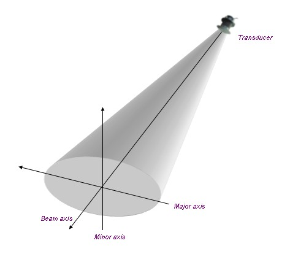

## Appendix E: List of participants

| Nolwenn Behagle | IRD | France | nolwenn.behagle@ird.fr |
| --- | --- | --- | --- |
| Laurent Berger | IFREMER | France | Laurent.Berger@ifremer.fr |
| Reka Domokos | NOAA | USA | Reka.Domokos@noaa.gov |
| Mathieu Doray | IFREMER | France | Mathieu.Doray@ifremer.fr |
| Adam Dunford | NIWA | New Zealand | adam.dunford@niwa.co.nz |
| Stephane Gauthier | DFO | Canada | Stephane.Gauthier@dfo-mpo.gc.ca |
| Keith, Gordon | CSIRO | Australia | gordon.keith@csiro.au |
| Mike Jech | NOAA | USA | michael.jech@noaa.gov |
| Erwan Josse | IRD | France | erwan.josse@ird.fr |
| Laura Kracker | NOAA | USA | Laura.Kracker@noaa.gov |
| Tomasz Laczkowski | MIR | Poland | tomasz.laczkowski@mir.gdynia.pl |
| Gavin Macaulay | IMR | Norway | gavin.macaulay@IMR.no |
| David Millington | Myriax Pty Ltd | Australia | davidm@echoview.com |
| Hassan Moustahfid | NOAA | USA | Hassan.Moustahfid@noaa.gov |
| Handegard, Nils Olav | Nils Olav | IMR | nilsolav@IMR.no |
| Richard O’Driscoll | NIWA | New Zealand | r.odriscoll@niwa.co.nz |
| Suzanne Romain | Consultant | USA | sromain@gmail.com |
| Tim Ryan (Chair) | CSIRO | Australia | tim.ryan@csiro.au |
| Chris Taylor | NOAA | USA | Chris.Taylor@noaa.gov |
| Sigurður Þór Jónsson | Hafro | Iceland | sigurdur@hafro.is |
| Brent Wood | NIWA | New Zealand | brent.wood@niwa.co.nz |

Jens Rasmussen, Marine Scotland Science, Marine Laboratory, is thanked for his review of this document.

## References

Some temporary citations (Simmonds and MacLennan, 2005; Foote *et al.*, 1987) because of a bug in asciidoctor, whereby citations inside tables are not seen (https://github.com/asciidoctor/asciidoctor-bibtex/issues/39).

Dublin Core. 2004. Dublin Core Metadata Initiative. http://dublincore.org/documents/2004/09/10/library-application-profile/.

Foote, K. G., Knudsen, H. P., Vestnes, G., MacLennan, D. N., and Simmonds, E. J. 1987. Calibration of Acoustic Instruments for Fish Density Estimation: A Practical Guide. ICES CRR No. 144.

MacLennan, D. N., Fernandes, P., and Dalen, J. 2002. A Consistent Approach to Definitions and Symbols in Fisheries Acoustics. ICES Journal of Marine Science, 59: 365–369.

Mitson, R. B. 1995. Underwater Noise of Research Vessels. ICES Cooperative Research Report No. 209.

Rew, R., and Davis, G. 1990. NetCDF: An Interface for Scientific Data Access. IEEE Computer Graphics and Applications, 10: 76–82.

Simmonds, J., and MacLennan, D. 2005. Fisheries Acoustics. Theory and Practice. Blackwell Science, Oxford.

Unidata. 2017. Network Common Data Form (netCDF) Version 4. UCAR/Unidata.

## Revisions

**Version 1.04. 21<sup>st</sup> August 2014**

Added new category of attributes, 'data' which describe the data type being stored and its dimensions (i.e. cell size).

Altered obligations on attributes from Mandatory (M) or Mandatory if Applicable (MA) to recommended (R) for ship_breadth, ship_tonnage, ship_engine_power, ship_noise_design and ship_acknowledgements.

Changed term data_processing_transceiver_gain to data_processing_on_axis_gain

Changed term data_processing_transceiver_gain_units to data_processing_on_axis_gain_units

Minor edits to improve readability in “Purpose of this document” section.

Added new attribute of “Convention” to the Metadata category.

**Version 1.10. 10<sup>th</sup> May 2016.**

The ICES Data Centre (Hjalte Parner, Nils Olav Handegard) are constructing an Acoustic Trawl Survey database with the intention of implementing the ICES Acoustic Metadata Standard. Through this process a number of new and existing attribute fields were discussed. This revision documents the consequent changes that were made as described below.

**Add**

Category: Cruise attributes: cruise_summary_report attribute.

**Add**

Category: Ship attributes: ship_platform_code using ICES database

**Add**

Category: Ship attributes: ship_platform_class using ICES database

**Add**

Category: Data processing: data_processing_triwave_correction

Minor edits to wording of Category Mooring: mooring_uplimit, mooring_downlimit, mooring_z_units.

Minor edits to wording of Category Transect: transect_uplimit, transect_downlimit, transect_z_units.

Minor edits to wording of Category Dataset: uplimit, downlimit and z_units.

**Add**

Category: Metadata record: convention_version

Revised convention version. Previous versions were using a decimal number series - e.g. version 1.01, 1.02 etc. limiting the minor number series to 99 revisions. This revision alters the convention to follow the more common convention in the computer world where the version number is described by two integers separated by a full stop. Thus following this convention our previous version 1.05 would now be version 1.5, that is the 5<sup>th</sup> revision in version 1 series. This version 1.10 is the 10<sup>th</sup> revision of the version 1 series.

**Revised**

**Add**

Category: Data attributes: data_range_axis_interval_value

**Version 2.0. 17<sup>th</sup> Feburary 2020**

Major revision. Added 'platform' category to allow long list of platform classes to be supported. These class types are defined by ICES controlled vocabulary. Mooring category attributes have been removed and can now be specified using the set of platform attributes.

Version 2.0  
Last updated 2020-03-19 00:24:04 UTC